# Лабораторная работа №4

Базовая настройка HTTP-сервера Apache

Устинова В. В.

Российский университет дружбы народов, Москва, Россия

26 сентября 2026

# Информация

## Докладчик

- Устинова Виктория Вадимовна
- студент НПИбд-01-24
- Российский университет дружбы народов

## Цель работы

Приобретение практических навыков по установке и базовому конфигурированию HTTP-сервера Apache.

## Задание

1. Установите необходимые для работы HTTP-сервера пакеты (см. раздел 4.4.1).
2. Запустите HTTP-сервер с базовой конфигурацией и проанализируйте его работу (см. разделы 4.4.2 и 4.4.3).
3. Настройте виртуальный хостинг (см. раздел 4.4.4).
4. Напишите скрипт для Vagrant, фиксирующий действия по установке и настройке HTTP-сервера во внутреннем окружении виртуальной машины server. Соответству- ющим образом внесите изменения в Vagrantfile (см. раздел 4.4.5).

## Выполнение лабораторной работы

Установить необходимые для работы HTTP-сервера пакеты. перед установкой просмтореть список достпуных групп пакетов командой LANG=C yum grouplist

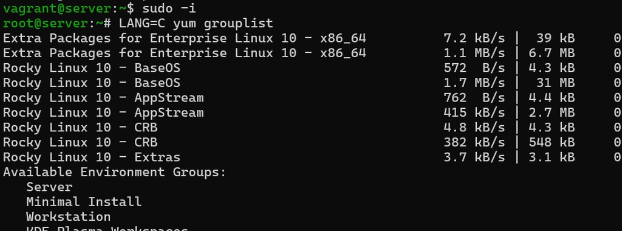

Выведен список групп пакетов среди которых server , minimal install, workstation,kde plasma workspaces

## Выполнение лабораторной работы

Установить стандартный веб-сервер командой dnf -y groupinstall “Basic Web Server

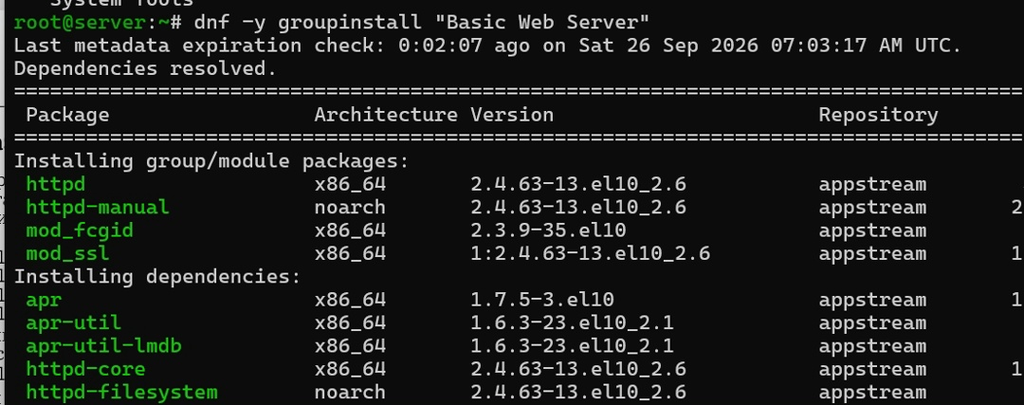

Установлены пакеты httpd, httpd-manual, mod_fcgid, mod_ssl и зависимости apr, apr-util, httpd-core, httpd-filesystem.

## Выполнение лабораторной работы

Просмотреть содержание конфигурационных файлов в каталогах /etc/httpd/conf и /etc/httpd/conf.d

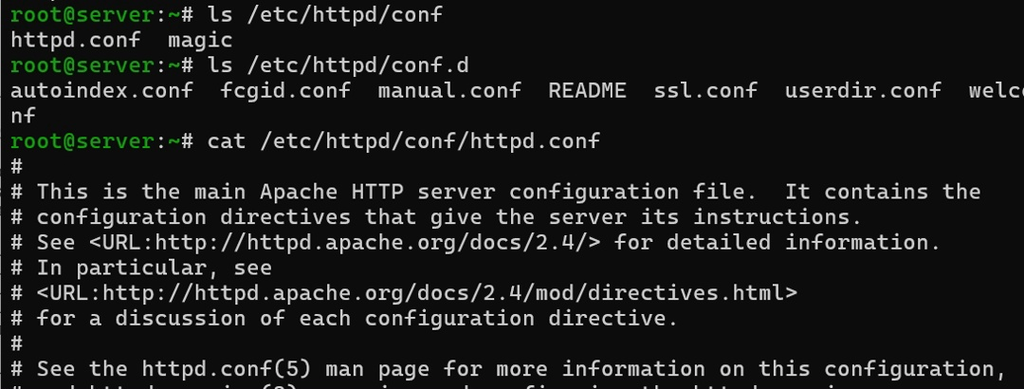

В /etc/httpd/conf находится httpd.conf и magic, в /etc/httpd/conf.d — autoindex.conf, fcgid.conf, manual.conf, ssl.conf, userdir.conf, welcome.conf.

## Выполнение лабораторной работы

Просмотреть и прокомментировать основный файл конфигурации веб-сервера httpd.conf

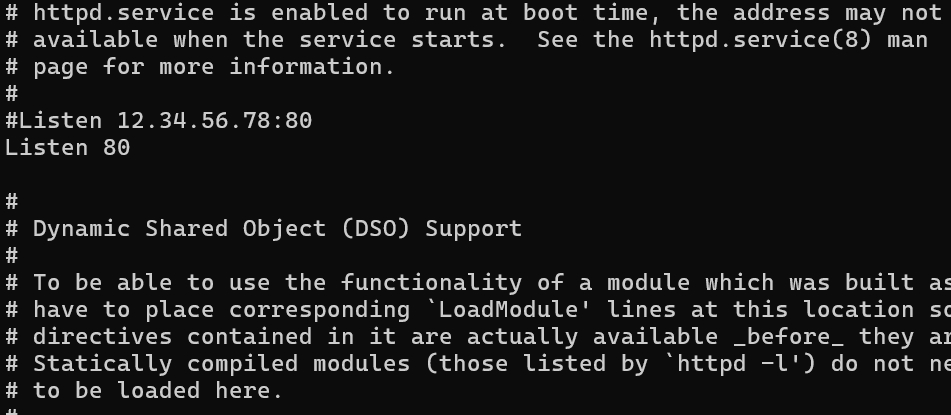

В файле приведены директивы, управляющие работой сервера, со ссылками на документацию Apache 2.4.

## Выполнение лабораторной работы

Изучить директивы httpd.conf, в частности настройки прослушивания портa

[figure not shown]

Директива Listen 80 указывает, что сервер прослушивает 80-й порт по умолчанию.

## Выполнение лабораторной работы

Внести изменения в настройки межсетевого экрана узла server, разрешив работу с http.

[figure not shown]

Выполнены команды firewall-cmd –add-service=http и firewall-cmd –add-service=http –permanent.

## Выполнение лабораторной работы

Активировать и запустить HTTP-сервер командой systemctl start httpd и systemctl status httpd, убедиться, что он успешно запустился

[figure not shown]

Служба httpd активна и работает, показаны дочерние процессы и PID.

## Выполнение лабораторной работы

На виртуальной машине server просмотреть лог ошибок работы веб-сервера командой tail -f /var/log/httpd/error_log.

[figure not shown]

В логе видно предупреждение о невозможности найти index.html в /var/www/html/

## Выполнение лабораторной работы

Запустить мониторинг доступа к веб-серверу командой tail -f /var/log/httpd/access_log и с клиента открыть страницу 192.168.1.1

[figure not shown]

В логе видны GET-запросы от клиента 192.168.1.30 к страницам /, /icons/poweredby.png и /favicon.ico.

## Выполнение лабораторной работы

На виртуальной машине client запустить браузер и в адресной строке ввести 192.168.1.1, проанализировать отобразившуюся страницу

[figure not shown]

В браузере открылась стандартная тестовая страница HTTP Server Test Page.

## Выполнение лабораторной работы

Остановить DNS-сервер и добавить запись для HTTP-сервера в конце файла прямой DNS-зоны /var/named/master/fz/vvustinova.net: www A 192.168.1.1

[figure not shown]

В файле прямой зоны добавлены записи для dhcp, ns, server и www с адресом 192.168.1.1.

## Выполнение лабораторной работы

Добавить запись для HTTP-сервера в конце файла обратной зоны /var/named/master/rz/192.168.1: 1 PTR www.vvustinova.net.

[figure not shown]

В файле обратной зоны добавлены PTR-записи для server, ns, dhcp, client и www.

## Выполнение лабораторной работы

Перезапустить DNS-сервер, удалить файлы журналов DNS и в каталоге /etc/httpd/conf.d создать файлы server.vvustinova.net.conf и www.vvustinova.net.conf

[figure not shown]

Выполнены systemctl stop/start named, удаление .jnl-файлов, создание конфигурационных файлов.

## Выполнение лабораторной работы

Открыть на редактирование файл server.vvustinova.net.conf и внести настройки виртуального хостa

[figure not shown]

В файле указаны VirtualHost *:80, ServerAdmin, DocumentRoot, ServerName, ErrorLog и CustomLog.

## Выполнение лабораторной работы

Открыть на редактирование файл www.vvustinova.net.conf и внести настройки виртуального хоста.

[figure not shown]

В файле указаны VirtualHost *:80, ServerAdmin, DocumentRoot, ServerName, ErrorLog и CustomLog.

## Выполнение лабораторной работы

Создать файл index.html в каталоге /var/www/html/server.vvustinova.net с приветственной строкой.

[figure not shown]

В файле записано Welcome to the server.vvustinova.net server.

## Выполнение лабораторной работы

Создать файл index.html в каталоге /var/www/html/www.vvustinova.net с приветственной строкой

[figure not shown]

В файле записано Welcome to the www.vvustinova.net server.

## Выполнение лабораторной работы

Проверить работу виртуального хостинга: в браузере открыть server.vvustinova.net

[figure not shown]

В браузере отобразилась страница Welcome to the server.vvustinova.net server.

## Выполнение лабораторной работы

Проверить работу виртуального хостинга: в браузере открыть www.vvustinova.net

[figure not shown]

В браузере отобразилась страница Welcome to the www.vvustinova.net server.

## Выполнение лабораторной работы

Исправить права доступа и контекст SELinux для каталогов /var/www и /etc, затем перезапустить HTTP-сервер.

[figure not shown]

Выполнены команды chown -R apache:apache /var/www, restorecon -vR /etc, /var/named, /var/www, systemctl restart httpd.

## Выполнение лабораторной работы

Создать исполняемый файл http.sh в каталоге /vagrant/provision/server, который повторяет действия по установке и настройке HTTP-сервера. В Vagrantfile добавить provision «server http».

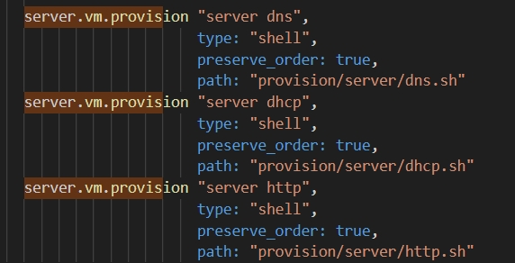

В скрипте прописаны установка Basic Web Server, копирование конфигураций, права, restorecon, firewall и запуск службы. В Vagrantfile добавлен provision с путём provision/server/http.sh.